# Compute Statistics from Card Draws

George Traskas

2017-07-04

## Distribution of Card Values

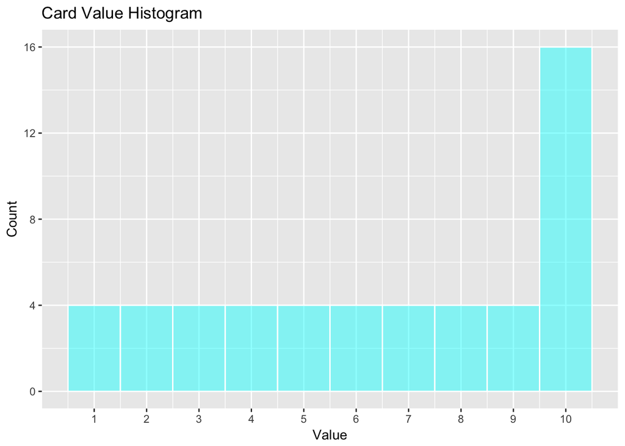

```r
# Load libraries.
library(ggplot2)


# Create the deck.
faces <- c("Ace", as.character(seq(2, 10)), "Jack", "Queen", "King")

deck <- data.frame(cards = c(paste0(faces, " of spades"),
                             paste0(faces, " of hearts"),
                             paste0(faces, " of diamonds"),
                             paste0(faces, " of clubs")),
                   values = rep(c(seq(1, 9), rep(10, times = 4)), times = 4),
                   stringsAsFactors = FALSE)

# Create the histogram.
ggplot(data = deck, aes(x = values)) +
  geom_histogram(binwidth = 1, alpha = 0.5, fill = "cyan", colour = "white") +
  labs(x = "Value", y = "Count", title = "Card Value Histogram") +
  scale_x_continuous(breaks = seq(1, 10), limits=c(0.5, 10.5)) +
  scale_y_continuous(breaks = seq(0, 16, 4))
```

- What is the mean of the card values for a single draw?
- What is the median of the card values for a single draw?
- What is the standard deviation of the card values for a single draw? (population sd)

```r
summary(deck)
```

```
##     cards               values
##  Length:52          Min.   : 1.000
##  Class :character   1st Qu.: 4.000
##  Mode  :character   Median : 7.000
##                     Mean   : 6.538
##                     3rd Qu.:10.000
##                     Max.   :10.000
```

```r
# Find the population sd.
sqrt(mean((deck$values-mean(deck$values))^2))
```

```
## [1] 3.152908
```

## Get Samples from the Deck of Cards

To obtain a single sample, shuffle your deck of cards and draw three cards from it. (You will be sampling from the deck without replacement.) Record the cards that you have drawn and the sum of the three cards??? values. Repeat this sampling procedure a total of at least thirty times.

```r
# The number of cards to pick
m <- 3

# The number of times to sample the deck
n <- 10000

# Initialize the data frame and name the columns.
samples <- data.frame(matrix(nrow = n, ncol = m + 1))
colnames(samples) <- c(paste0("card", seq(1:m)), "sum")

# Sample the deck n times, drawing m cards.
set.seed(1)
for(s in seq(1, n)) {
  pick_m <- sample(52, size = m)
  # Populate the samples data frame. First, populate the cards.
  samples[s, 1:m] <- deck$cards[pick_m]
  # Then, populate the sum column.
  samples$sum[s] <-sum(deck$values[pick_m])
}
```

## Distribution of Values

```r
# Get descriptive statistics.
summary(samples)
```

```
##     card1              card2              card3                sum
##  Length:10000       Length:10000       Length:10000       Min.   : 3.00
##  Class :character   Class :character   Class :character   1st Qu.:16.00
##  Mode  :character   Mode  :character   Mode  :character   Median :20.00
##                                                           Mean   :19.65
##                                                           3rd Qu.:24.00
##                                                           Max.   :30.00
```

```r
# Create the mode function.
getmode <- function(v) {
   uniqv <- unique(v)
   uniqv[which.max(tabulate(match(v, uniqv)))]
}

# Find the mode.
getmode(samples$sum)
```

```
## [1] 21
```

```r
# Find the variance.
var(samples$sum)
```

```
## [1] 28.61136
```

```r
# Find the standard deviation of the samples.
sd(samples$sum)
```

```
## [1] 5.348959
```

- Measures of central tendency
  - Mean: 19.65
  - Median: 20
  - Mode: 21
- Measures of variation
  - IQR: 8
  - Variance: 28.61136
  - Standard Deviation: 5.348959

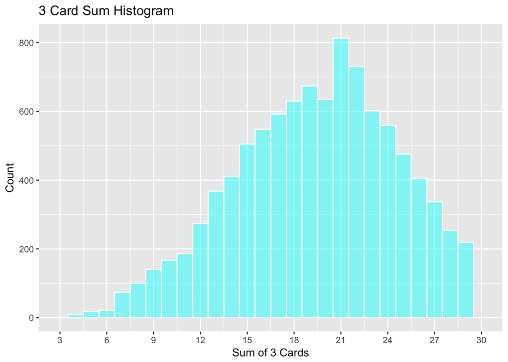

```r
ggplot(data = samples, aes(x = sum)) +
  geom_histogram(binwidth = 1, alpha = 0.5, fill = "cyan", colour = "white") +
  labs(x = "Sum of 3 Cards", y = "Count", title = "3 Card Sum Histogram") +
  scale_x_continuous(breaks = seq(3, 30, 3), limits=c(3, 30))
```

- What range of values do you expect 90% of three-card draw sums to fall into?

90% of the draw values should fall within the 5th and 95th percentile. The z-scores that correspond to these percentiles are -1.645 and 1.645, respectively. For our estimated mean of 19.65 and our estimated standard deviation of 5.35, these z-scores correspond to:

z = (x - sample_mean) / SE => -1.645 = (x - 19.65) / 5.35 => x = 10.86

z = (x - sample_mean) / SE => 1.645 = (x - 19.65) / 5.35 => x = 28.45

Therefore, we expect approximately 90% of the draw values to fall in the range (10.86, 28.45).

- How likely are you to get a draw of at least 20 from a random draw?

Using our estimated mean and standard deviation, 20 corresponds to a z-score of:

z = (x - sample_mean) / SE => z = (20 - 19.65) / 5.35 => z = 0.065

Using this, we find that the probability that the draw value will be less than 20 is 0.526. Therefore, the probability that the draw value will be at least 20 is 0.474.